# Test - extract environmental data for coordinates from Copernicus marine - package copernicus (xyzt)

OHW 2022

2022-08-19

This is a test run using package copernicus developed during OceanHackWeek2022 to extract environmental data for coordinates of interest (e.g. sampling stations) from [Copernicus marine service](https://marine.copernicus.eu).  
The test script downloads the very first dataset in the catalogue, [GLOBAL_ANALYSIS_FORECAST_PHY_001_024 (Global Ocean 1/12° Physics Analysis and Forecast updated Daily)](https://resources.marine.copernicus.eu/product-detail/GLOBAL_ANALYSIS_FORECAST_PHY_001_024/INFORMATION).  
I’m also using my MSFD dataset for 2017, containing zoobenthic stations in the Bulgarian Black Sea sampled by IO-BAS for the national MSFD monitoring. There are separate coordinates for each replicate sample, sampling dates, and station depths in meters.

## Setup

Package copernicus can be installed from Github. See readme for installation instructions and other requirements.  
A (free) Copernicus account is required to download data; the readme explains how to store the credentials in the R environment.

Load necessary packages.

```r
library(tidyverse)
library(here)
library(xyzt)
library(copernicus)
```

Define the working directory using package here (= project directory, ohw22-proj-xyzt), by giving it the path to the current file, relative to the project root.

```r
here::i_am("notebook/test_covars_extraction_with_copernicus.Rmd")
```

```
here() starts at /media/sklayn/data/data/rabota/kursove/ocean_hack_week_2022/ohw22-proj-xyzt
```

## Import data

Read in my example dataset (in the data subdirectory). It’s a csv file.

```r
(msfd <- read_csv(here("data", "msfd_2017_meta.csv")) %>%
     ## remove units from depth column name
     rename(depth = depth_m)
)
```

| station_code_repl | date | lat | lon | depth |
| --- | --- | --- | --- | --- |
| ZB1_1 | 2017-10-21 | 43.70905 | 28.64502 | 35.0 |
| ZB1_2 | 2017-10-21 | 43.70908 | 28.64468 | 35.0 |
| ZB3_1 | 2017-10-21 | 43.70857 | 28.85297 | 56.0 |
| ZB3_2 | 2017-10-21 | 43.70875 | 28.85288 | 56.0 |
| ZB5_1 | 2017-10-20 | 43.69460 | 29.26325 | 66.0 |
| ZB5_2 | 2017-10-20 | 43.69438 | 29.26332 | 66.0 |
| ZB11_1 | 2017-10-21 | 43.63672 | 28.60980 | 26.5 |
| ZB11_2 | 2017-10-21 | 43.63695 | 28.60972 | 26.5 |
| ZB14_1 | 2017-10-20 | 43.62188 | 28.98698 | 63.0 |
| ZB14_2 | 2017-10-20 | 43.62265 | 28.98603 | 63.0 |

[output cut: 161 more lines]

Transform to spatial points - ignore the dates and depths for now.

```r
(msfd.sp <- msfd %>%
    as_POINT(dims = "xy")
)
```

```
Simple feature collection with 171 features and 3 fields
Geometry type: POINT
Dimension:     XY
Bounding box:  xmin: 27.54567 ymin: 41.99233 xmax: 29.33717 ymax: 43.70908
Geodetic CRS:  WGS 84
```

|  | station_code_repl | date | depth | geometry |
| --- | --- | --- | --- | --- |
| 1 | ZB1_1 | 2017-10-21 | 35.0 |  |
| 2 | ZB1_2 | 2017-10-21 | 35.0 |  |
| 3 | ZB3_1 | 2017-10-21 | 56.0 |  |
| 4 | ZB3_2 | 2017-10-21 | 56.0 |  |
| 5 | ZB5_1 | 2017-10-20 | 66.0 |  |
| 6 | ZB5_2 | 2017-10-20 | 66.0 |  |
| 7 | ZB11_1 | 2017-10-21 | 26.5 |  |
| 8 | ZB11_2 | 2017-10-21 | 26.5 |  |
| 9 | ZB14_1 | 2017-10-20 | 63.0 |  |
| 10 | ZB14_2 | 2017-10-20 | 63.0 |  |

[output cut: 161 more lines]

## Download Copernicus data

The package contains a script for constructing the server request for a given dataset and bounding box of interest. The coordinates for the bounding box are in the order **lon_min, lon_max, lat_min, lat_max**. The dates and depth of interest can also be specified.  
The script downloads the whole bounding box, from which the environmental parameters values at whatever coordinates can be extracted.

Define the bounding box of interest (W Black Sea - somewhat arbitrarily defined here) and download data.

```r
## insert the bounding box coordinates in the script (lon_min, lon_max, lat_min, lat_max)
tst.script <- populate_script(bb = c(27.44547, 30.67082, 41.96027, 44.03979),
                              out_name = here("data", "copernicus_2022-08-19.nc")) ## put downloaded file in data folder

download_copernicus(tst.script)
```

Read in the downloaded file.

```r
(bs <- read_copernicus(here("data", "copernicus_2022-08-19.nc")))
```

```
stars object with 2 dimensions and 11 attributes
attribute(s):
               Min.     1st Qu.       Median        Mean     3rd Qu.       Max. NA's
mlotst    7.4770352 10.52888627 10.528886274 10.52390835 10.52888627 11.1392565  203
siconc           NA          NA           NA         NaN          NA         NA 1000
thetao   25.0328379 25.39613025 25.582171082 25.68414717 25.93008209 27.5465865  203
usi              NA          NA           NA         NaN          NA         NA 1000
sithick          NA          NA           NA         NaN          NA         NA 1000
bottomT   7.5933409  8.83629873  8.848750278 10.21562262  8.85387739 27.1371502  203
vsi              NA          NA           NA         NaN          NA         NA 1000
vo       -0.2972503 -0.11047700 -0.024414808 -0.04080597  0.02319407  0.1202429  203
uo       -0.1599170 -0.04577776 -0.003051851 -0.01448270  0.01770074  0.1129185  203
so       14.0705588 17.49320962 18.559831521 18.05955006 18.78566849 18.9443647  203
zos      -0.5227821 -0.48524430 -0.437635425 -0.44011443 -0.39521470 -0.3555406  203
dimension(s):
```

|  | from | to | offset | delta | refsys | point | values | x/y |
| --- | --- | --- | --- | --- | --- | --- | --- | --- |
| x | 1 | 40 | 27.375 | 0.0833333 | WGS 84 | NA | NULL | [x] |
| y | 1 | 25 | 44.0417 | -0.0833333 | WGS 84 | NA | NULL | [y] |

Extract the values of the environmental variables at the sampling stations.

```r
(vars <- stars::st_extract(bs, at = msfd.sp))
```

```
Simple feature collection with 171 features and 11 fields
Geometry type: POINT
Dimension:     XY
Bounding box:  xmin: 27.54567 ymin: 41.99233 xmax: 29.33717 ymax: 43.70908
Geodetic CRS:  WGS 84
First 10 features:
     mlotst siconc   thetao usi sithick   bottomT vsi           vo           uo       so
1  10.52889     NA 25.87075  NA      NA 20.075655  NA  0.002441481  0.003662221 14.75112
2  10.52889     NA 25.87075  NA      NA 20.075655  NA  0.002441481  0.003662221 14.75112
3  10.52889     NA 25.54262  NA      NA  9.285287  NA -0.059816279 -0.023804437 14.97543
4  10.52889     NA 25.54262  NA      NA  9.285287  NA -0.059816279 -0.023804437 14.97543
5  10.52889     NA 25.22108  NA      NA  7.976409  NA -0.112308115 -0.053102206 17.94794
6  10.52889     NA 25.22108  NA      NA  7.976409  NA -0.112308115 -0.053102206 17.94794
7        NA     NA       NA  NA      NA        NA  NA           NA           NA       NA
8        NA     NA       NA  NA      NA        NA  NA           NA           NA       NA
9  10.52889     NA 25.30897  NA      NA  8.043794  NA -0.142216254 -0.069582202 17.03543
10 10.52889     NA 25.30897  NA      NA  8.043794  NA -0.142216254 -0.069582202 17.03543
          zos                  geometry
1  -0.3723258 POINT (28.64502 43.70905)
2  -0.3723258 POINT (28.64468 43.70908)
3  -0.3750725 POINT (28.85297 43.70857)
4  -0.3750725 POINT (28.85288 43.70875)
5  -0.4260384  POINT (29.26325 43.6946)
6  -0.4260384 POINT (29.26332 43.69438)
7          NA  POINT (28.6098 43.63672)
8          NA POINT (28.60972 43.63695)
9  -0.4062014 POINT (28.98698 43.62188)
10 -0.4062014 POINT (28.98603 43.62265)
```

Plot one of the parameters (bottom temperature) - for the whole downloaded area and only for the bounding box defined by the sampling stations.

```r
## define the bounding box of the sampling stations
bbox <- msfd.sp %>%
    xyzt::as_BBOX()

## subset the downloaded Copernicus dataset to only this bounding box
(sub <- bs[bbox])
```

```
stars object with 2 dimensions and 11 attributes
attribute(s):
               Min.     1st Qu.        Median        Mean      3rd Qu.       Max. NA's
mlotst    7.4770352 10.52888627 10.5288862735 10.51874162 10.528886274 11.1392565  123
siconc           NA          NA            NA         NaN           NA         NA  484
thetao   25.0328379 25.34559160 25.4818262234 25.69261596 25.930082090 27.5465865  123
usi              NA          NA            NA         NaN           NA         NA  484
sithick          NA          NA            NA         NaN           NA         NA  484
bottomT   7.5933409  8.81872007  8.8465529457 11.54912200 10.816095471 27.1371502  123
vsi              NA          NA            NA         NaN           NA         NA  484
vo       -0.2972503 -0.13672292 -0.0811792351 -0.07157055  0.009155553  0.1190222  123
uo       -0.1599170 -0.03540147 -0.0006103702 -0.00799399  0.019531846  0.1129185  123
so       14.9403363 16.79738760 17.5496688578 17.58087636 18.601031508 18.9016388  123
zos      -0.4763939 -0.43336283 -0.3967406228 -0.40723358 -0.383007294 -0.3555406  123
dimension(s):
```

|  | from | to | offset | delta | refsys | point | values | x/y |
| --- | --- | --- | --- | --- | --- | --- | --- | --- |
| x | 3 | 24 | 27.375 | 0.0833333 | WGS 84 | NA | NULL | [x] |
| y | 4 | 25 | 44.0417 | -0.0833333 | WGS 84 | NA | NULL | [y] |

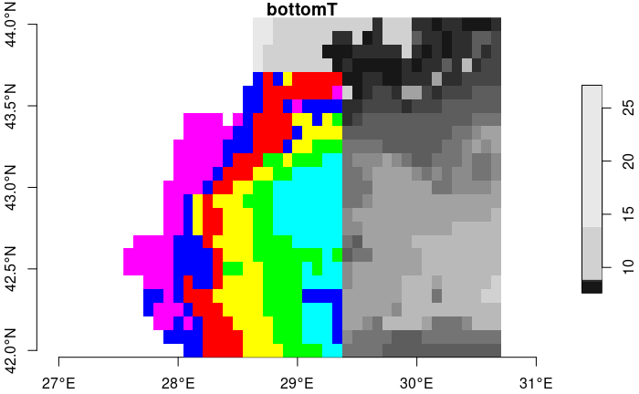

```r
## plot one of the parameters
plot(bs['bottomT'], axes = TRUE, reset = FALSE)
plot(sub['bottomT'], add = TRUE, col = rainbow(6), main = NULL)
```